# Multi-Stage Attack Graph Simulation Via Markov Chains

- Show All Code
- Hide All Code
- View Source

Closed-Form Time to Resolution and Absorption Probabilities for Containment versus Catastrophic Breach

Author

Patrick Lefler

Published

August 27, 2026

Abstract

Enterprise security programs still lean on static checklists and heatmaps to describe attacks that are anything but static: adversaries move through a sequence of tactical stages, and the pace of that progression influences whether an incident ends in containment or catastrophe. This project models that progression as an absorbing Markov chain in R. Six transient states span a kill-chain-style progression from initial phishing delivery through privilege escalation, lateral movement, and domain compromise, ending in one of three absorbing outcomes: contained or terminated, data exfiltration, or enterprise ransomware. The Fundamental Matrix, computed by closed-form inversion of (I − Q), yields expected time to resolution and the probability of each terminal outcome, given the assumed transition matrix and without simulation. Under the illustrative baseline parameters, expected time to resolution falls from 14.2 hours for an attack starting at phishing delivery to 4.2 hours at payload staging, and catastrophic outcomes become more likely than containment at privilege escalation (52.9% versus 47.1%). An illustrative improved posture raises containment from the phishing stage from 72.5% to 97.3% (+24.8 percentage points). The transition probabilities are expert-elicited illustrative values, not calibrated to any cited benchmark or internal telemetry. A Dirichlet parameter-uncertainty analysis and a one-row-at-a-time control sensitivity analysis qualify the point estimates. Operational use would require recalibration against SIEM data and tabletop exercise results.

### Introduction

Enterprise cyber defenses have traditionally relied on static checklists and subjective risk heatmaps that do not capture how adversaries maneuver through networks over time. When advanced persistent threats (APTs) or ransomware operators infiltrate an organization, they do not execute a single isolated attack; they work through a sequence of tactical stages, from initial delivery to privilege escalation and lateral movement. Traditional security metrics rarely quantify the speed of this progression or the likelihood of catastrophic outcomes relative to early containment.

This project implements a **multi-stage cyber attack simulator using absorbing Markov chains in R**. The attack is modeled as a set of transient stages and permanent absorbing outcomes. Using the Fundamental Matrix framework, we compute, for an assumed transition matrix, the closed-form probability that an attack ends in containment versus data exfiltration or ransomware, and the expected time to resolution. The goal is to illustrate how such a model can support discussion of detection and response priorities. It is not a validated risk quantification: the inputs are illustrative (see Parameterization and Assumptions).

**Display code**

```
%%{init: {'themeVariables': { 'fontSize': '14px', 'fontFamily': 'sans-serif' }}}%%
flowchart LR
    S1["<b>S1: Recon & Phishing</b><br>(Perimeter Delivery)"] --> S2["<b>S2: Initial Foothold</b><br>(Endpoint Breach)"]
    S2 --> S3["<b>S3: Priv Escalation</b><br>(Credential Theft)"]
    S2 --> S4
    S3 --> S4["<b>S4: Lateral Movement</b><br>(Network Discovery)"]
    S3 --> S5
    S4 --> S3
    S4 --> S5["<b>S5: Domain Dominance</b><br>(Active Directory)"]
    S4 --> S6
    S5 --> S6["<b>S6: Payload Staging</b><br>(Arming Assets)"]

    S1 -.-> A1["<b>A1: Contained / Terminated</b>"]
    S2 -.-> A1
    S3 -.-> A1
    S4 -.-> A1
    S5 -.-> A1
    S6 -.-> A1
    S5 -.-> A2["<b>A2: Data Exfiltration</b>"]
    S5 -.-> A3["<b>A3: Enterprise Ransomware</b>"]
    S6 -.-> A2
    S6 -.-> A3

    classDef default fill:#f8f9fa,stroke:#0275d8,stroke-width:1.5px;
    classDef good fill:#e4f4e4,stroke:#5cb85c,stroke-width:1.5px;
    classDef alert fill:#fce4e4,stroke:#d9534f,stroke-width:1.5px;
    class A1 good;
    class A2,A3 alert;
```

```
%%{init: {'themeVariables': { 'fontSize': '14px', 'fontFamily': 'sans-serif' }}}%%
flowchart LR
    S1["<b>S1: Recon & Phishing</b><br>(Perimeter Delivery)"] --> S2["<b>S2: Initial Foothold</b><br>(Endpoint Breach)"]
    S2 --> S3["<b>S3: Priv Escalation</b><br>(Credential Theft)"]
    S2 --> S4
    S3 --> S4["<b>S4: Lateral Movement</b><br>(Network Discovery)"]
    S3 --> S5
    S4 --> S3
    S4 --> S5["<b>S5: Domain Dominance</b><br>(Active Directory)"]
    S4 --> S6
    S5 --> S6["<b>S6: Payload Staging</b><br>(Arming Assets)"]

    S1 -.-> A1["<b>A1: Contained / Terminated</b>"]
    S2 -.-> A1
    S3 -.-> A1
    S4 -.-> A1
    S5 -.-> A1
    S6 -.-> A1
    S5 -.-> A2["<b>A2: Data Exfiltration</b>"]
    S5 -.-> A3["<b>A3: Enterprise Ransomware</b>"]
    S6 -.-> A2
    S6 -.-> A3

    classDef default fill:#f8f9fa,stroke:#0275d8,stroke-width:1.5px;
    classDef good fill:#e4f4e4,stroke:#5cb85c,stroke-width:1.5px;
    classDef alert fill:#fce4e4,stroke:#d9534f,stroke-width:1.5px;
    class A1 good;
    class A2,A3 alert;
```

*Solid arrows are transitions among transient stages (forward, skip, and the S4 → S3 back-edge); dotted arrows are transitions into absorbing outcomes. Self-loops are omitted for readability.*

### Mathematical Foundation: The Fundamental Matrix Framework

By organizing all attack states into a standardized matrix, the model separates transient stages (where the attacker is actively maneuvering) from absorbing states (permanent outcomes). Through closed-form matrix inversion, it computes the expected time spent in each stage and the probability of each terminal outcome, conditional on the assumed transition matrix.

#### Canonical Block Form

Let the state space contain $t$ transient states and $r$ absorbing states ($n = t + r$). The transition probability matrix $P \in \mathbb{R}^{n \times n}$ is partitioned into canonical block form:

$$P = \begin{pmatrix} Q & R \\ \mathbf{0} & I_r \end{pmatrix}$$

- $Q \in \mathbb{R}^{t \times t}$: Transition probabilities between transient states.
- $R \in \mathbb{R}^{t \times r}$: Transition probabilities from transient states into absorbing states.
- $\mathbf{0} \in \mathbb{R}^{r \times t}$: Zero matrix (absorbing states cannot transition back to transient states).
- $I_r \in \mathbb{R}^{r \times r}$: Identity matrix of order $r$ (absorbing states are permanent).

#### The Fundamental Matrix ($N$)

If every transient state can reach an absorbing state, $(I_t - Q)$ is invertible. The **Fundamental Matrix** $N \in \mathbb{R}^{t \times t}$ is:

$$N = (I_t - Q)^{-1} = I_t + Q + Q^2 + Q^3 + \dots = \sum_{k=0}^{\infty} Q^k$$

Each entry $N_{ij}$ is the **expected number of time steps** spent in transient state $j$, given that the attack starts in transient state $i$. Because $N = I + Q + \dots$, the starting step counts: $N_{ii} \ge 1$.

#### Expected Time to Resolution ($\mathbf{t}$)

The expected number of steps before the chain is absorbed, from any starting state, is

$$\mathbf{t} = N \mathbf{1} = \sum_{j=1}^t N_{ij}$$

This is the expected time to **resolution of any kind**, including containment. A shorter time to resolution can mean faster containment (good) or faster detonation (bad), so it is not by itself a measure of adversary dwell. Each stage $j$ has its own mean step duration $h_j$ (hours), giving

$$\mathbf{T} = N \mathbf{h}$$

In this document every $h_j = \Delta\tau = 4$ hours, so $\mathbf{T} = 4\,\mathbf{t}$. The 4-hour step is an assumption, and every time in hours scales linearly with it.

#### Absorption Probabilities ($B$)

The matrix $B \in \mathbb{R}^{t \times r}$ gives the probability that an attack starting in transient state $i$ ends in absorbing state $k$:

$$B = N R, \qquad \sum_{k=1}^r B_{ik} = 1 \;\; \text{for all } i$$

#### Conditional Time to Each Outcome

The expected time to resolution, conditional on ending in outcome $k$, has the closed form

$$E[T \mid \text{start } i,\ \text{absorbed in } k] = \frac{\left(N\,(\mathbf{h} \circ B_{\cdot k})\right)_i}{B_{ik}}$$

where $\circ$ is the elementwise product. For a catastrophic outcome, $B_{\cdot k}$ is replaced by $B_{\cdot A2} + B_{\cdot A3}$. This is the time metric that bears on response timelines, because it separates “time until containment” from “time until a catastrophic outcome, given that one occurs.”

### R Library Initialization

Only a small set of packages is used. A seed is set because the parameter-uncertainty analysis and the simulation check draw random numbers; the closed-form solver itself is deterministic.

**Display code**

```r
library(tidyverse)
library(scales)
library(patchwork)
library(gt)

set.seed(42)

theme_set(
  theme_minimal(base_size = 12) +
    theme(
      plot.title = element_text(face = "bold", size = 13, color = "#1a1a1a"),
      plot.subtitle = element_text(color = "#555555", size = 10.5),
      panel.grid.minor = element_blank(),
      legend.position = "bottom"
    )
)

pct1 <- function(x) sprintf("%.1f%%", 100 * x)
pp1 <- function(x) sprintf("%.1f pp", 100 * x)
```

#### Parameterization and Assumptions

The model has six transient states (kill-chain-style stages) and three absorbing states (outcomes). **Transition probabilities are expert-elicited, illustrative values.** They are not calibrated to any cited benchmark, and they were typed in by hand: no asset graph, PageRank, CVSS weighting, or loss distribution is computed. Each transient row gives the per-step probability, from a given stage, of staying (self-loop), advancing, regressing, or ending in an absorbing outcome. The baseline and the improved-posture matrices are two hand-set matrices; the improved posture is not derived from any specific control (MFA, EDR, or Zero Trust).

Assumptions that the results depend on:

- **Markov property.** “Starting at $S_i$” and “having reached $S_i$” are treated as identical, and the per-step detection hazard is constant. An attacker who reached $S_3$ after 30 hours of slow movement has the same future as one who arrived in 4 hours; real detection probability can build up with time and noise.
- **Geometric holding times and a single step length.** Each stage has a geometric holding time, with a step length of $\Delta\tau = 4$ hours for all stages. Real stages differ by orders of magnitude (phishing delivery in minutes, directory reconnaissance in days). Publicly reported median dwell times are on the order of days, so the implied time scale here (a kill chain resolved in under a day) is a hypothetical, not a benchmark.
- **S1 is not adversary dwell.** At phishing delivery the adversary is not yet inside the environment, so time spent in S1 is time to resolution, not dwell time in the industry sense.
- **Outcome space.** “Contained / Terminated” (A1) includes automated filtering, user non-engagement, abandoned attacks, and SOC action; it should not be read as “SOC wins.” A2 and A3 are mutually exclusive here, although double extortion (exfiltrate, then encrypt) is common; “catastrophic” counts only the first catastrophic outcome, and the A2/A3 split is not meaningful by itself.
- **Graph structure.** Only S5 and S6 can reach A2/A3, and S6 has no regression edge, so catastrophic probability is largely P(reach S5/S6) times the S5/S6 exit split. The single back-edge S4 → S3 (0.05) is an illustrative attacker-backtracking edge with no empirical basis, kept in both regimes.

**Display code**

```r
transient_names <- c(
  "S1: Recon & Phishing",
  "S2: Initial Foothold",
  "S3: Privilege Escalation",
  "S4: Lateral Movement",
  "S5: Domain Dominance",
  "S6: Payload Staging"
)

absorbing_names <- c(
  "A1: Contained / Terminated",
  "A2: Data Exfiltration",
  "A3: Enterprise Ransomware"
)

all_state_names <- c(transient_names, absorbing_names)
t_dim <- length(transient_names)
r_dim <- length(absorbing_names)

# Mean step duration per transient stage (hours); 4 h for every stage by assumption
step_hours <- setNames(rep(4, t_dim), transient_names)

# Baseline transition matrix P (9x9), illustrative values
# Row order: S1..S6, A1..A3 | Col order: S1..S6, A1..A3
P_baseline_raw <- matrix(0, nrow = 9, ncol = 9, dimnames = list(all_state_names, all_state_names))

P_baseline_raw["S1: Recon & Phishing", ]       <- c(0.10, 0.65, 0.00, 0.00, 0.00, 0.00, 0.25, 0.00, 0.00)
P_baseline_raw["S2: Initial Foothold", ]       <- c(0.00, 0.15, 0.55, 0.05, 0.00, 0.00, 0.25, 0.00, 0.00)
P_baseline_raw["S3: Privilege Escalation", ]   <- c(0.00, 0.00, 0.10, 0.60, 0.10, 0.00, 0.20, 0.00, 0.00)
P_baseline_raw["S4: Lateral Movement", ]       <- c(0.00, 0.00, 0.05, 0.15, 0.55, 0.10, 0.15, 0.00, 0.00)
P_baseline_raw["S5: Domain Dominance", ]       <- c(0.00, 0.00, 0.00, 0.00, 0.10, 0.70, 0.10, 0.05, 0.05)
P_baseline_raw["S6: Payload Staging", ]        <- c(0.00, 0.00, 0.00, 0.00, 0.00, 0.05, 0.10, 0.40, 0.45)

P_baseline_raw[absorbing_names, absorbing_names] <- diag(r_dim)

# Improved-posture matrix: A1 probabilities rise by 2.0x to 3.5x depending on stage
P_hardened_raw <- P_baseline_raw
P_hardened_raw["S1: Recon & Phishing", ]       <- c(0.05, 0.40, 0.00, 0.00, 0.00, 0.00, 0.55, 0.00, 0.00)
P_hardened_raw["S2: Initial Foothold", ]       <- c(0.00, 0.10, 0.35, 0.05, 0.00, 0.00, 0.50, 0.00, 0.00)
P_hardened_raw["S3: Privilege Escalation", ]   <- c(0.00, 0.00, 0.05, 0.40, 0.05, 0.00, 0.50, 0.00, 0.00)
P_hardened_raw["S4: Lateral Movement", ]       <- c(0.00, 0.00, 0.02, 0.10, 0.40, 0.08, 0.40, 0.00, 0.00)
P_hardened_raw["S5: Domain Dominance", ]       <- c(0.00, 0.00, 0.00, 0.00, 0.05, 0.50, 0.35, 0.05, 0.05)
P_hardened_raw["S6: Payload Staging", ]        <- c(0.00, 0.00, 0.00, 0.00, 0.00, 0.05, 0.35, 0.30, 0.30)

# Every row must be a probability distribution
stopifnot(all(abs(rowSums(P_baseline_raw) - 1) < 1e-8))
stopifnot(all(abs(rowSums(P_hardened_raw) - 1) < 1e-8))

Q_base <- P_baseline_raw[1:t_dim, 1:t_dim]
R_base <- P_baseline_raw[1:t_dim, (t_dim + 1):(t_dim + r_dim)]
Q_hard <- P_hardened_raw[1:t_dim, 1:t_dim]
R_hard <- P_hardened_raw[1:t_dim, (t_dim + 1):(t_dim + r_dim)]
```

### Pure R Algebraic Solver: Fundamental Matrix & Time to Resolution

The solver computes $N$, expected time to resolution, absorption probabilities, and conditional times to each outcome. Before inverting, it checks that every transient state can reach an absorbing state (which guarantees $I - Q$ is invertible) and, after computing $B$, that every row of $B$ sums to 1.

**Display code**

```r
# TRUE if every transient state has a path to an absorbing state
all_reach_absorbing <- function(Q, R) {
  reach <- rowSums(R) > 0
  repeat {
    updated <- reach | as.vector((Q > 0) %*% reach) > 0
    if (identical(updated, reach)) break
    reach <- updated
  }
  all(reach)
}

solve_absorbing_markov <- function(Q, R, h) {
  stopifnot(all_reach_absorbing(Q, R))

  N <- solve(diag(nrow(Q)) - Q, tol = 1e-14)
  dimnames(N) <- dimnames(Q)

  B <- N %*% R
  stopifnot(all(abs(rowSums(B) - 1) < 1e-8))

  # Conditional expected time to each outcome: N (h * B_k) / B_k
  time_given_outcome <- apply(B, 2, \(b) as.vector(N %*% (h * b)) / b)
  rownames(time_given_outcome) <- rownames(Q)

  cat_prob <- B[, 2] + B[, 3]
  time_given_catastrophe <- as.vector(N %*% (h * cat_prob)) / cat_prob

  list(
    N = N,
    B = B,
    steps = rowSums(N),
    hours = as.vector(N %*% h) |> setNames(rownames(Q)),
    time_given_outcome = time_given_outcome,
    time_given_catastrophe = setNames(time_given_catastrophe, rownames(Q))
  )
}

base_solution <- solve_absorbing_markov(Q_base, R_base, step_hours)
hard_solution <- solve_absorbing_markov(Q_hard, R_hard, step_hours)
```

**Display code**

```r
# One row per starting stage; all prose numbers below are drawn from this table
res <- tibble(
  stage = transient_names,
  steps_b = base_solution$steps,
  hours_b = base_solution$hours,
  hours_h = hard_solution$hours,
  cont_b = base_solution$B[, 1],
  cont_h = hard_solution$B[, 1],
  cat_b = base_solution$B[, 2] + base_solution$B[, 3],
  cat_h = hard_solution$B[, 2] + hard_solution$B[, 3],
  uplift = cont_h - cont_b,
  t_cont_b = base_solution$time_given_outcome[, 1],
  t_cat_b = base_solution$time_given_catastrophe
)

# First stage where catastrophic outcomes are more likely than containment
cross_stage <- which(res$cat_b > res$cont_b)[1]

# The abstract is static YAML, so verify it matches the model
stopifnot(
  round(res$hours_b[1], 1) == 14.2, round(res$hours_b[6], 1) == 4.2,
  round(100 * res$cat_b[3], 1) == 52.9, round(100 * res$cont_b[3], 1) == 47.1,
  round(100 * res$cont_b[1], 1) == 72.5, round(100 * res$cont_h[1], 1) == 97.3,
  round(100 * res$uplift[1], 1) == 24.8, cross_stage == 3
)
```

### Diagnostic Visualizations & Attack Frontiers

The diagnostic plots below show the routing structure of the transition matrix, the expected time to resolution from each starting stage, the conditional time to each outcome, the baseline absorption probabilities, and the change in catastrophic probability under the improved posture.

#### The Transition Probability Matrix (P) plot

The heatmap shows the main paths an intrusion can take under the assumed parameters and where the per-step exit probabilities sit.

**Display code**

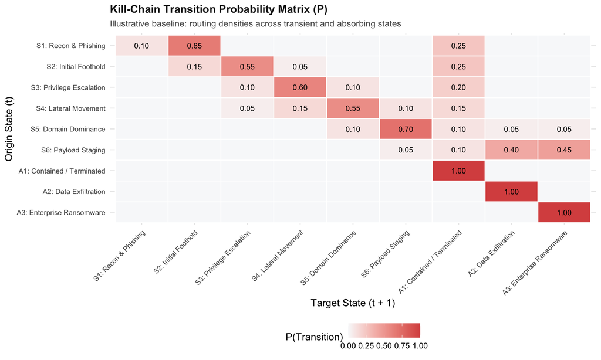

```r
matrix_df <- as.data.frame(P_baseline_raw) |>
  rownames_to_column(var = "From_State") |>
  pivot_longer(cols = -From_State, names_to = "To_State", values_to = "Probability") |>
  mutate(
    From_State = factor(From_State, levels = rev(all_state_names)),
    To_State = factor(To_State, levels = all_state_names)
  )

p1_heatmap <- ggplot(matrix_df, aes(x = To_State, y = From_State, fill = Probability)) +
  geom_tile(color = "white", linewidth = 0.5) +
  geom_text(aes(label = ifelse(Probability > 0, sprintf("%.2f", Probability), "")), size = 3.2) +
  scale_fill_gradient(low = "#f8f9fa", high = "#d9534f", limits = c(0, 1), name = "P(Transition)") +
  labs(
    title = "Kill-Chain Transition Probability Matrix (P)",
    subtitle = "Illustrative baseline: routing densities across transient and absorbing states",
    x = "Target State (t + 1)",
    y = "Origin State (t)"
  ) +
  theme(axis.text.x = element_text(angle = 45, hjust = 1, size = 8.5),
        axis.text.y = element_text(size = 8.5))

p1_heatmap
```

**How to read the plot**

The matrix works like a flight board: the vertical axis is where the attacker currently is (origin state) and the horizontal axis is where they can move in the next step (target state). Every row sums to 1.00. The darker the red, the higher the transition probability.

1. **Transient stages ($S_1$ to $S_6$).** These are temporary phases in which the adversary is actively maneuvering. The diagonal holds the small self-loops (0.05 to 0.15); the forward momentum sits on the **super-diagonal**.
2. **Absorbing outcomes ($A_1$ to $A_3$).** Once the chain reaches one of these columns the incident is over. $A_1$ is contained or terminated (SOC action, automated filtering, user non-engagement, or an abandoned attack); $A_2$ is data exfiltration; $A_3$ is enterprise ransomware.
3. **The bottom-right block.** $A_1$, $A_2$, and $A_3$ each have 1.00 on the diagonal and zeros elsewhere: these are absorbing states, and an ended incident does not return to earlier stages.

**How to interpret the results**

**Directional momentum.** The super-diagonal carries the largest transient-to-transient probabilities (0.65 from S1 to S2, 0.55 S2 to S3, 0.60 S3 to S4, 0.55 S4 to S5, 0.70 S5 to S6), so under these parameters an attack that is not stopped keeps advancing.

**Per-step exit probabilities to A1.** The per-step probability of ending in $A_1$ is 0.25 at S1 and 0.25 at S2, and falls to 0.10 at S6, where the per-step catastrophic probability is 0.85. These are assumed inputs, not findings, so they cannot by themselves show where defensive investment pays off most; the one-row-at-a-time analysis below addresses that question.

#### The Expected Time to Resolution Plot

The expected time to resolution is the expected time until the incident ends in any outcome, including containment. It is not adversary dwell time: a shorter value can reflect faster containment or faster detonation.

**Display code**

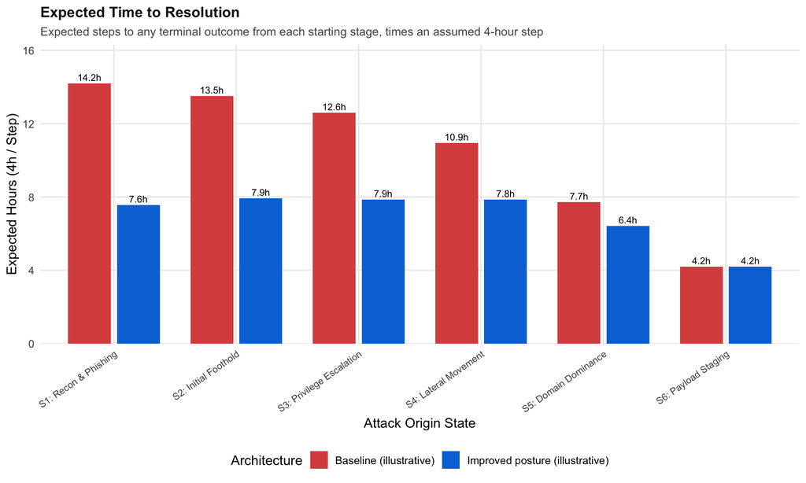

```r
dwell_df <- res |>
  select(Origin_State = stage, Baseline = hours_b, Improved = hours_h) |>
  pivot_longer(cols = c(Baseline, Improved), names_to = "Architecture", values_to = "Hours") |>
  mutate(
    Origin_State = factor(Origin_State, levels = transient_names),
    Architecture = recode(Architecture,
      Baseline = "Baseline (illustrative)",
      Improved = "Improved posture (illustrative)"
    )
  )

p2_dwell <- ggplot(dwell_df, aes(x = Origin_State, y = Hours, fill = Architecture)) +
  geom_col(position = position_dodge(width = 0.8), width = 0.7) +
  geom_text(aes(label = sprintf("%.1fh", Hours)), position = position_dodge(width = 0.8), vjust = -0.4, size = 3) +
  scale_fill_manual(values = c("Baseline (illustrative)" = "#d9534f", "Improved posture (illustrative)" = "#0275d8")) +
  scale_y_continuous(expand = expansion(mult = c(0, 0.15))) +
  labs(
    title = "Expected Time to Resolution",
    subtitle = "Expected steps to any terminal outcome from each starting stage, times an assumed 4-hour step",
    x = "Attack Origin State",
    y = "Expected Hours (4h / Step)"
  ) +
  theme(axis.text.x = element_text(angle = 35, hjust = 1, size = 8.5))

p2_dwell
```

**How to interpret the results**

**Time to resolution shortens with depth.** Under the baseline, expected time to resolution falls from 3.5 steps (14.2 hours) for an attack starting at S1 to 1.1 steps (4.2 hours) at S6. Part of this is mechanical, since there are fewer stages left to traverse; part is outcome mix.

**The improved posture shortens it mainly through earlier containment.** From S1 through S3 the improved posture lowers the expected time to resolution from 12.6–14.2 hours to 7.6–7.9 hours, but the plot cannot separate faster containment (good) from faster detonation (bad); the conditional times below can.

**The S6 values are identical by construction.** The baseline and improved S6 rows share the same self-loop (0.05), so S6 shows 4.2 hours in both regimes. This is a parameter choice, not a finding about late-stage defense.

#### Conditional Time to Containment versus Time to a Catastrophic Outcome

**Display code**

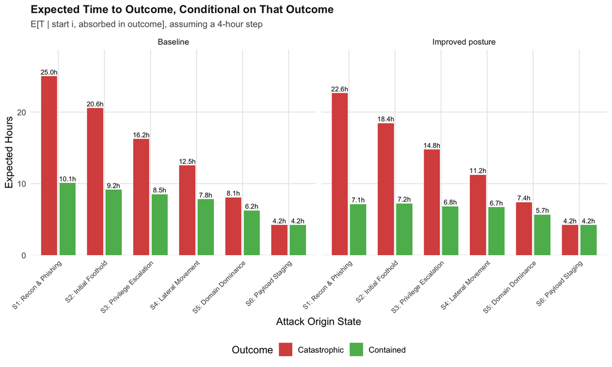

```r
cond_df <- bind_rows(
  tibble(Regime = "Baseline", Origin_State = transient_names,
         Contained = base_solution$time_given_outcome[, 1],
         Catastrophic = base_solution$time_given_catastrophe),
  tibble(Regime = "Improved posture", Origin_State = transient_names,
         Contained = hard_solution$time_given_outcome[, 1],
         Catastrophic = hard_solution$time_given_catastrophe)
) |>
  pivot_longer(cols = c(Contained, Catastrophic), names_to = "Outcome", values_to = "Hours") |>
  mutate(
    Origin_State = factor(Origin_State, levels = transient_names),
    Regime = factor(Regime, levels = c("Baseline", "Improved posture"))
  )

p_cond <- ggplot(cond_df, aes(x = Origin_State, y = Hours, fill = Outcome)) +
  geom_col(position = position_dodge(width = 0.8), width = 0.7) +
  geom_text(aes(label = sprintf("%.1fh", Hours)), position = position_dodge(width = 0.8), vjust = -0.4, size = 2.8) +
  facet_wrap(~Regime) +
  scale_fill_manual(values = c(Contained = "#5cb85c", Catastrophic = "#d9534f")) +
  scale_y_continuous(expand = expansion(mult = c(0, 0.15))) +
  labs(
    title = "Expected Time to Outcome, Conditional on That Outcome",
    subtitle = "E[T | start i, absorbed in outcome], assuming a 4-hour step",
    x = "Attack Origin State",
    y = "Expected Hours"
  ) +
  theme(axis.text.x = element_text(angle = 45, hjust = 1, size = 8))

p_cond
```

**How to interpret the results.** Conditional on ending in a catastrophic outcome, the baseline expected time to that outcome is 25.0 hours from S1, versus 10.1 hours to containment. The metric that bears on a response timeline is the first: under these assumptions, an attack that starts at phishing delivery and goes on to a catastrophic outcome takes about 25 hours to get there. This figure scales linearly with the assumed 4-hour step and rests on the memoryless assumption.

#### The Baseline Terminal Absorption Frontier Plot

The plot decomposes the final outcome of an attack by starting stage, under the baseline parameters.

**Display code**

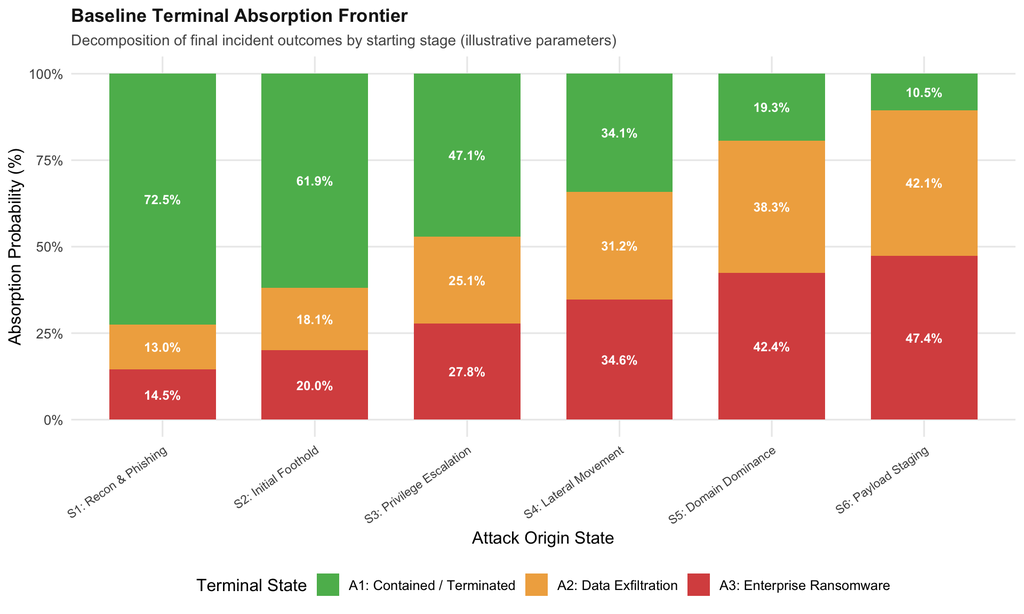

```r
absorb_df <- as.data.frame(base_solution$B) |>
  rownames_to_column(var = "Origin_State") |>
  pivot_longer(cols = -Origin_State, names_to = "Absorbing_Outcome", values_to = "Probability") |>
  mutate(
    Origin_State = factor(Origin_State, levels = transient_names),
    Absorbing_Outcome = factor(Absorbing_Outcome, levels = absorbing_names)
  )

p3_frontier <- ggplot(absorb_df, aes(x = Origin_State, y = Probability, fill = Absorbing_Outcome)) +
  geom_col(width = 0.7) +
  geom_text(aes(label = sprintf("%.1f%%", Probability * 100)),
            position = position_stack(vjust = 0.5), size = 3.2, color = "white", fontface = "bold") +
  scale_fill_manual(
    values = setNames(c("#5cb85c", "#f0ad4e", "#d9534f"), absorbing_names)
  ) +
  scale_y_continuous(labels = percent_format()) +
  labs(
    title = "Baseline Terminal Absorption Frontier",
    subtitle = "Decomposition of final incident outcomes by starting stage (illustrative parameters)",
    x = "Attack Origin State",
    y = "Absorption Probability (%)",
    fill = "Terminal State"
  ) +
  theme(axis.text.x = element_text(angle = 35, hjust = 1, size = 8.5))

p3_frontier
```

**How to interpret the results**

**Containment declines with depth.** Under the baseline parameters, the probability of ending in $A_1$ falls from 72.5% for an attack starting at S1 to 47.1% at S3, where catastrophic outcomes (52.9%) first become more likely than containment. This crossing follows directly from the hand-set S2 and S3 rows; the uncertainty analysis below shows how stable it is.

**Catastrophic probability rises steeply.** Combined catastrophic probability (A2 plus A3) grows from 27.5% at S1 to 80.7% at S5 and 89.5% at S6.

**The A2/A3 split should not be over-read.** At S5 and S6 the split is roughly even (A2 38.3%–42.1%, A3 42.4%–47.4%), but A2 and A3 are modeled as mutually exclusive, whereas double extortion is common in practice. In the improved-posture matrix, A2 equals A3 at S5 and S6 because the two columns were assigned identical values, which shows the split is a parameter choice.

#### The Catastrophic Breach Risk Under an Improved Posture

The plot contrasts baseline catastrophic probability with the illustrative improved posture. The improved-posture matrix changes **all six rows at once**, so differences across starting stages reflect where the attacker begins, not where a control is applied.

**Display code**

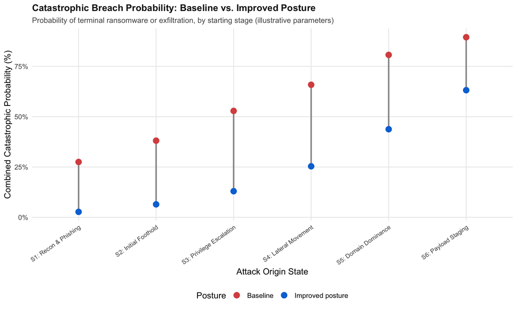

```r
comparison_df <- res |>
  transmute(
    Origin_State = factor(stage, levels = transient_names),
    Baseline_Catastrophic = cat_b * 100,
    Hardened_Catastrophic = cat_h * 100
  )

p4_reduction <- ggplot(comparison_df, aes(x = Origin_State)) +
  geom_segment(aes(xend = Origin_State, y = Hardened_Catastrophic, yend = Baseline_Catastrophic),
               color = "gray60", linewidth = 1) +
  geom_point(aes(y = Baseline_Catastrophic, color = "Baseline"), size = 3.5) +
  geom_point(aes(y = Hardened_Catastrophic, color = "Improved posture"), size = 3.5) +
  scale_color_manual(values = c("Baseline" = "#d9534f", "Improved posture" = "#0275d8"), name = "Posture") +
  scale_y_continuous(labels = function(x) paste0(x, "%")) +
  labs(
    title = "Catastrophic Breach Probability: Baseline vs. Improved Posture",
    subtitle = "Probability of terminal ransomware or exfiltration, by starting stage (illustrative parameters)",
    x = "Attack Origin State",
    y = "Combined Catastrophic Probability (%)"
  ) +
  theme(axis.text.x = element_text(angle = 35, hjust = 1, size = 8.5))

p4_reduction
```

**How to interpret the results**

**Lower catastrophic probability at every stage.** By construction, the improved posture (blue) lowers combined catastrophic probability relative to the baseline (red) from every starting stage.

**Where the absolute reductions are largest.** The reductions in catastrophic probability are 24.8, 31.6, 39.9, 40.5, 36.9, 26.3 percentage points for S1 through S6. The largest absolute reductions occur at **S4: Lateral Movement** and **S3: Privilege Escalation**.

**Why S1 shows the lowest residual risk.** From S1 the catastrophic probability falls from 27.5% to 2.7%, versus 89.5% to 63.2% from S6. This is guaranteed by the setup: an attacker starting at S1 passes through all six hardened rows, one starting at S6 only through the last. It is not evidence that upstream investment has greater leverage. The next section tests that question directly.

### One-Row-at-a-Time Control Sensitivity

To ask where a control change has the most leverage, the comparison must change **one row at a time** and hold the starting stage fixed. Starting from S1 (so every row lies on the attacker’s path), the analysis applies two changes to each row separately: (a) a standardized shift of 0.05 of probability from the row’s largest non-self, non-A1 edge to A1, and (b) replacing that row with its improved-posture row.

**Display code**

```r
harden_one_row <- function(P, i, delta = 0.05) {
  donor <- unname(which.max(replace(P[i, ], c(i, 7), 0)))
  P[i, donor] <- P[i, donor] - delta
  P[i, 7] <- P[i, 7] + delta
  list(P = P, donor = all_state_names[donor])
}

outcomes_from_s1 <- function(P) {
  B <- solve_absorbing_markov(P[1:t_dim, 1:t_dim], P[1:t_dim, 7:9], step_hours)$B
  c(cont = B[1, 1], cat = B[1, 2] + B[1, 3])
}

base_s1 <- outcomes_from_s1(P_baseline_raw)

sens_df <- map(seq_len(t_dim), \(i) {
  shifted <- harden_one_row(P_baseline_raw, i)
  full_row <- P_baseline_raw
  full_row[i, ] <- P_hardened_raw[i, ]

  tibble(
    Stage = transient_names[i],
    Donor_Edge = str_extract(shifted$donor, "^[SA][0-9]"),
    Shift_Cont = outcomes_from_s1(shifted$P)["cont"] - base_s1["cont"],
    Shift_Cat = outcomes_from_s1(shifted$P)["cat"] - base_s1["cat"],
    Row_Cont = outcomes_from_s1(full_row)["cont"] - base_s1["cont"],
    Row_Cat = outcomes_from_s1(full_row)["cat"] - base_s1["cat"]
  )
}) |>
  list_rbind()

sens_df |>
  gt() |>
  tab_header(
    title = "One-Row-at-a-Time Control Sensitivity (Attack Starting at S1)",
    subtitle = "Change in outcome probabilities from S1 when only one stage's row is changed"
  ) |>
  cols_label(
    Stage = "Row changed",
    Donor_Edge = "Donor edge (0.05 moved to A1)",
    Shift_Cont = "Δ Containment, standardized shift (pp)",
    Shift_Cat = "Δ Catastrophic, standardized shift (pp)",
    Row_Cont = "Δ Containment, improved row (pp)",
    Row_Cat = "Δ Catastrophic, improved row (pp)"
  ) |>
  fmt_number(columns = c(Shift_Cont, Shift_Cat, Row_Cont, Row_Cat), scale_by = 100, decimals = 2) |>
  tab_options(table.font.size = 11, heading.title.font.size = 13.5, heading.subtitle.font.size = 11)
```

One-Row-at-a-Time Control Sensitivity (Attack Starting at S1)

Change in outcome probabilities from S1 when only one stage's row is changed

| Row changed | Donor edge (0.05 moved to A1) | Δ Containment, standardized shift (pp) | Δ Catastrophic, standardized shift (pp) | Δ Containment, improved row (pp) | Δ Catastrophic, improved row (pp) |
| --- | --- | --- | --- | --- | --- |
| S1: Recon & Phishing | S2 | 2.12 | −2.12 | 11.47 | −11.47 |
| S2: Initial Foothold | S3 | 2.25 | −2.25 | 10.01 | −10.01 |
| S3: Privilege Escalation | S4 | 1.78 | −1.78 | 10.07 | −10.07 |
| S4: Lateral Movement | S5 | 1.75 | −1.75 | 7.50 | −7.50 |
| S5: Domain Dominance | S6 | 1.46 | −1.46 | 6.76 | −6.76 |
| S6: Payload Staging | A3 | 1.43 | −1.43 | 7.13 | −7.13 |

**Display code**

```r
best_row <- which.max(sens_df$Shift_Cont)
```

**How to interpret the results**

Under these illustrative parameters, the largest standardized containment gain from S1 comes from changing the **S2: Initial Foothold** row (2.25 pp), not S1 itself (2.12 pp). Gains decline for deeper rows, to 1.43 pp at S6, which is 36% below the best row. So upstream rows do carry more leverage here, but the gradient is moderate (the best row is about 1.6 times the last), not the sharp contrast suggested by comparing 27.5% to 2.7% across starting stages. Two caveats: the 0.05 shift is a different relative change in each row, and the table only covers attacks that start at S1. The ranking reflects the hand-set parameters.

### Parameter Uncertainty (Dirichlet)

Closed-form results are exact only **given $P$**, and $P$ is uncertain. To quantify that, each transient row is treated as Dirichlet($\alpha \cdot p_{\text{row}}$) over its non-zero entries (structural zeros stay zero), with concentration $\alpha = 50$ as a stand-in for “moderate confidence” in the elicited values. The solver is re-run on 5,000 sampled matrices per regime.

**Display code**

```r
alpha_conc <- 50
n_draws <- 5000

draw_P <- function(P, alpha) {
  for (i in seq_len(t_dim)) {
    idx <- which(P[i, ] > 0)
    g <- rgamma(length(idx), shape = alpha * P[i, idx])
    P[i, idx] <- g / sum(g)
  }
  P
}

summarise_draw <- function(P) {
  sol <- solve_absorbing_markov(P[1:t_dim, 1:t_dim], P[1:t_dim, 7:9], step_hours)
  tibble(Stage = transient_names, cont = sol$B[, 1], cat = sol$B[, 2] + sol$B[, 3], hours = sol$hours)
}

set.seed(42)
draws <- map(seq_len(n_draws), \(d) {
  b <- summarise_draw(draw_P(P_baseline_raw, alpha_conc))
  h <- summarise_draw(draw_P(P_hardened_raw, alpha_conc))
  tibble(draw = d, Stage = b$Stage,
         cont_b = b$cont, cat_b = b$cat, hours_b = b$hours,
         cont_h = h$cont, cat_h = h$cat, hours_h = h$hours)
}) |>
  list_rbind() |>
  mutate(Stage = factor(Stage, levels = transient_names))

q05 <- \(x) quantile(x, 0.05)
q95 <- \(x) quantile(x, 0.95)

unc_summary <- draws |>
  summarise(
    cont_b_lo = q05(cont_b), cont_b_hi = q95(cont_b),
    cat_b_lo = q05(cat_b), cat_b_hi = q95(cat_b),
    hours_b_lo = q05(hours_b), hours_b_hi = q95(hours_b),
    p_improved_better = mean(cont_h > cont_b),
    .by = Stage
  ) |>
  left_join(res |> select(Stage = stage, cont_b, cat_b, hours_b) |> mutate(Stage = factor(Stage, levels = transient_names)),
            by = "Stage") |>
  arrange(Stage)

unc_summary |>
  transmute(
    Stage,
    Containment = sprintf("%.1f%% (%.1f–%.1f)", 100 * cont_b, 100 * cont_b_lo, 100 * cont_b_hi),
    Catastrophic = sprintf("%.1f%% (%.1f–%.1f)", 100 * cat_b, 100 * cat_b_lo, 100 * cat_b_hi),
    Hours = sprintf("%.1f (%.1f–%.1f)", hours_b, hours_b_lo, hours_b_hi),
    p_improved_better
  ) |>
  gt() |>
  tab_header(
    title = "Baseline Outcomes with 90% Parameter-Uncertainty Intervals",
    subtitle = sprintf("Point estimate (5th–95th percentile); Dirichlet α = %d, %s draws", alpha_conc, format(n_draws, big.mark = ","))
  ) |>
  cols_label(
    Containment = "Containment",
    Catastrophic = "Catastrophic",
    Hours = "Time to resolution (h)",
    p_improved_better = "P(improved > baseline containment)"
  ) |>
  fmt_number(columns = p_improved_better, decimals = 3) |>
  tab_options(table.font.size = 11, heading.title.font.size = 13.5, heading.subtitle.font.size = 11)
```

Baseline Outcomes with 90% Parameter-Uncertainty Intervals

Point estimate (5th–95th percentile); Dirichlet α = 50, 5,000 draws

| Stage | Containment | Catastrophic | Time to resolution (h) | P(improved > baseline containment) |
| --- | --- | --- | --- | --- |
| S1: Recon & Phishing | 72.5% (64.0–80.2) | 27.5% (19.8–36.0) | 14.2 (12.2–16.3) | 1.000 |
| S2: Initial Foothold | 61.9% (52.1–71.1) | 38.1% (28.9–47.9) | 13.5 (11.8–15.3) | 1.000 |
| S3: Privilege Escalation | 47.1% (36.5–57.7) | 52.9% (42.3–63.5) | 12.6 (11.2–14.0) | 1.000 |
| S4: Lateral Movement | 34.1% (23.9–45.1) | 65.9% (54.9–76.1) | 10.9 (9.9–12.1) | 1.000 |
| S5: Domain Dominance | 19.3% (10.9–29.0) | 80.7% (71.0–89.1) | 7.7 (7.2–8.3) | 1.000 |
| S6: Payload Staging | 10.5% (4.4–18.8) | 89.5% (81.2–95.6) | 4.2 (4.0–4.5) | 0.999 |

**Display code**

```r
crossing_dist <- draws |>
  summarise(
    cross = which(cat_b > cont_b)[1],
    .by = draw
  ) |>
  count(cross) |>
  mutate(share = n / sum(n))

p_cross_s3 <- crossing_dist |> filter(cross == 3) |> pull(share)
```

The improved-posture comparison draws baseline and improved matrices independently, so the last column checks whether the improvement survives parameter noise, not a paired control effect.

**How to interpret the results**

**The S3 crossing is fairly, not fully, stable.** In 63.7% of draws, catastrophic outcomes first become more likely than containment at S3 (the baseline point estimate); the remaining draws place the crossing at other stages (shares: S2 2.6%; S3 63.7%; S4 32.8%; S5 1.0%). The statement “S3 is the tipping point” is therefore conditional on these parameters and on the assumed concentration $\alpha$; a different $\alpha$ would change the interval widths.

**Uncertainty is substantial for the point estimates.** At S3 the 90% interval for catastrophic probability is 42.3% to 63.5%, around the point estimate of 52.9%.

**The improved posture is robustly better.** The improved posture has higher containment than the baseline in at least 99.9% of draws at every stage. Since the improved matrix was built to have higher A1 probabilities, this mostly confirms that the gap is large relative to Dirichlet noise; it does not validate any control.

### Simulation Check of the Closed-Form Solver

A short Monte Carlo run from S1 under the baseline matrix is a code-correctness check on $B$ and $\mathbf{t}$ (not a substitute for them: simulation is still needed for time-to-outcome percentiles and for propagating parameter uncertainty).

**Display code**

```r
simulate_walk <- function(P, start) {
  s <- start
  steps <- 0
  while (s <= t_dim) {
    s <- sample.int(ncol(P), 1, prob = P[s, ])
    steps <- steps + 1
  }
  c(outcome = s - t_dim, steps = steps)
}

set.seed(42)
n_sim <- 20000
sims <- map(seq_len(n_sim), \(k) simulate_walk(P_baseline_raw, 1)) |>
  map(\(v) tibble(outcome = v[["outcome"]], steps = v[["steps"]])) |>
  list_rbind()

sim_check <- tibble(
  Quantity = c(absorbing_names, "Expected steps from S1"),
  Closed_form = c(base_solution$B[1, ], base_solution$steps[1]),
  Simulated = c(prop.table(table(factor(sims$outcome, levels = 1:3))), mean(sims$steps))
)

stopifnot(all(abs(sim_check$Closed_form - sim_check$Simulated) < 0.03))

sim_check |>
  gt() |>
  fmt_number(columns = c(Closed_form, Simulated), decimals = 3) |>
  cols_label(Closed_form = "Closed form", Simulated = sprintf("Monte Carlo (%s walks)", format(n_sim, big.mark = ",")))
```

| Quantity | Closed form | Monte Carlo (20,000 walks) |
| --- | --- | --- |
| A1: Contained / Terminated | 0.725 | 0.723 |
| A2: Data Exfiltration | 0.130 | 0.130 |
| A3: Enterprise Ransomware | 0.145 | 0.146 |
| Expected steps from S1 | 3.548 | 3.554 |

### Scorecard

The scorecard summarizes the closed-form metrics under the illustrative baseline and improved-posture matrices. Time to resolution is shown in steps first and hours second.

**Display code**

```r
scorecard_table <- res |>
  transmute(
    Kill_Chain_Stage = stage,
    Baseline_Steps = steps_b,
    Baseline_Hours = hours_b,
    Baseline_Containment_Pct = cont_b * 100,
    Baseline_Catastrophic_Pct = cat_b * 100,
    Hardened_Containment_Pct = cont_h * 100,
    Hardened_Catastrophic_Pct = cat_h * 100,
    Containment_Uplift_pp = (cont_h - cont_b) * 100
  )

scorecard_table |>
  gt() |>
  tab_header(
    title = "Kill-Chain Absorption Scorecard",
    subtitle = "Closed-form absorbing Markov chain metrics: baseline vs. illustrative improved posture"
  ) |>
  cols_label(
    Kill_Chain_Stage = "Starting Stage",
    Baseline_Steps = "Time to Resolution (steps)",
    Baseline_Hours = "Time to Resolution (hours)",
    Baseline_Containment_Pct = "Containment (Base)",
    Baseline_Catastrophic_Pct = "Catastrophic (Base)",
    Hardened_Containment_Pct = "Containment (Improved)",
    Hardened_Catastrophic_Pct = "Catastrophic (Improved)",
    Containment_Uplift_pp = "Containment Uplift (pp)"
  ) |>
  fmt_number(columns = Baseline_Steps, decimals = 1) |>
  fmt_number(columns = Baseline_Hours, decimals = 1, pattern = "{x} hrs") |>
  fmt_percent(columns = c(Baseline_Containment_Pct, Baseline_Catastrophic_Pct,
                          Hardened_Containment_Pct, Hardened_Catastrophic_Pct),
              scale_values = FALSE, decimals = 1) |>
  fmt_number(columns = Containment_Uplift_pp, decimals = 1, pattern = "+{x} pp") |>
  data_color(
    columns = Baseline_Catastrophic_Pct,
    direction = "column",
    palette = c("#ffffff", "#f8d7da", "#d9534f")
  ) |>
  data_color(
    columns = Hardened_Containment_Pct,
    direction = "column",
    palette = c("#ffffff", "#d4edda", "#5cb85c")
  ) |>
  tab_options(
    table.font.size = 11,
    heading.title.font.size = 13.5,
    heading.subtitle.font.size = 11
  )
```

Kill-Chain Absorption Scorecard

Closed-form absorbing Markov chain metrics: baseline vs. illustrative improved posture

| Starting Stage | Time to Resolution (steps) | Time to Resolution (hours) | Containment (Base) | Catastrophic (Base) | Containment (Improved) | Catastrophic (Improved) | Containment Uplift (pp) |
| --- | --- | --- | --- | --- | --- | --- | --- |
| S1: Recon & Phishing | 3.5 | 14.2 hrs | 72.5% | 27.5% | 97.3% | 2.7% | +24.8 pp |
| S2: Initial Foothold | 3.4 | 13.5 hrs | 61.9% | 38.1% | 93.5% | 6.5% | +31.6 pp |
| S3: Privilege Escalation | 3.1 | 12.6 hrs | 47.1% | 52.9% | 87.0% | 13.0% | +39.9 pp |
| S4: Lateral Movement | 2.7 | 10.9 hrs | 34.1% | 65.9% | 74.6% | 25.4% | +40.5 pp |
| S5: Domain Dominance | 1.9 | 7.7 hrs | 19.3% | 80.7% | 56.2% | 43.8% | +36.9 pp |
| S6: Payload Staging | 1.1 | 4.2 hrs | 10.5% | 89.5% | 36.8% | 63.2% | +26.3 pp |

**How to read the table**

**Starting Stage:** The stage where the attack starts, treated as equivalent to “having reached” that stage (Markov assumption).

**Time to Resolution:** Expected time until the incident ends in any outcome, including containment, in steps and in hours at an assumed 4 hours per step. Not adversary dwell time.

**Containment (Base / Improved):** Probability of ending in A1, contained or terminated, under the baseline and the illustrative improved posture.

**Catastrophic (Base / Improved):** Probability of ending in A2 or A3 (counts only the first catastrophic outcome).

**Containment Uplift (pp):** The change in containment probability, in **percentage points**, between the two matrices. It is a difference between two hand-set matrices, not a measured return on investment.

**How to interpret the results of the scorecard**

**Catastrophic outcomes overtake containment at S3.** Under the baseline parameters, catastrophic probability rises from 38.1% at S2 to 52.9% at S3 (versus 47.1% containment) and reaches 89.5% by S6. This is a consequence of the hand-set parameters, and the uncertainty analysis above attaches a 90% interval of 42.3%–63.5% to the S3 value. It is suggestive that identity and credential controls matter around this stage, but it does not show that perimeter defense alone is insufficient.

**The window shortens with depth.** Expected time to resolution falls from 14.2 hours at S1 to 4.2 hours at S6, a decline of 70%. This is the time to any resolution; it shrinks partly because fewer stages remain. The time scale rests on the assumed 4-hour step.

**Improvement from a hand-set matrix.** Moving from the baseline to the illustrative improved posture raises containment by 24.8 to 40.5 percentage points depending on the starting stage, with the largest uplifts at S3 and S4 (39.9 and 40.5 pp). Because all rows change together, this does not identify which stage’s control matters most; see the one-row-at-a-time table.

**Scorecard Insights**

**Insight 1 (Early-Stage Response Time):** Under the baseline, an attack starting at *S1: Recon & Phishing* has an expected time to resolution of 14.2 hours; conditional on ending in a catastrophic outcome, the expected time to that outcome is 25.0 hours. Response targets such as MTTD under 4 hours and MTTR under 8 hours on initial endpoint compromises are consistent with this picture of neutralizing activity before *S3: Privilege Escalation*, but they follow from the assumed 4-hour step, not from the model, and should be set from observed dwell times.

**Insight 2 (Active Directory Tier-0 Isolation):** If an adversary reaches *S5: Domain Dominance*, the baseline probability of a catastrophic outcome is 80.7% (above 80%). Under these parameters that supports prioritizing segregation of identity infrastructure; the figure is a function of the assumed S5 row, not a measured rate.

**Insight 3 (Control Prioritization):** Moving to the illustrative improved posture raises containment for an attack starting at S1 from 72.5% to 97.3% (+24.8 pp). Hardening one row at a time, the largest standardized containment gain from S1 comes from S2: Initial Foothold, with gains declining for deeper rows. This illustrates how a control improvement translates into outcome probabilities; investment decisions require cost and loss inputs that this model does not contain.

### Insights & Conclusions

This project illustrates how an attack progression can be represented as an absorbing Markov chain and solved in closed form. Six kill-chain-style stages lead to three outcomes, and the Fundamental Matrix gives, for an assumed transition matrix, the expected time to resolution and the outcome probabilities from every starting stage, without simulation. Under the illustrative baseline, expected time to resolution falls from 14.2 hours at S1 to 4.2 hours at S6, and catastrophic outcomes become more likely than containment at S3 (52.9% versus 47.1%; 90% parameter-uncertainty interval 42.3%–63.5% for the catastrophic probability). The closed form is exact given $P$, but $P$ is uncertain, which is why the intervals matter.

On where to act, the evidence is more limited than a comparison across starting stages suggests. The one-row-at-a-time analysis shows the largest marginal containment gain from S1 at the **S2: Initial Foothold** row, with a moderate decline for later rows. That is a more defensible basis for prioritizing than the contrast between starting stages, which the setup guarantees. Whether any real control (MFA, EDR, Zero Trust) corresponds to these parameter changes is not something this model can establish: there are no costs, loss magnitudes, or control-to-parameter mapping. Loss quantification, including any Cyber Value-at-Risk (CyVaR) figure, would need a stated loss mapping that is not part of this version.

The closed-form solution replaces simulation for expected values and absorption probabilities; Monte Carlo is still needed for time-to-outcome percentiles and parameter uncertainty (the simulation check above reproduces $B$ and $\mathbf{t}$ as a correctness test). Other limitations are listed under Parameterization and Assumptions: the memoryless property, constant per-step hazard, geometric holding times, a single assumed step length, the mutually exclusive A2/A3 outcomes, and hand-set probabilities that are not calibrated to any cited benchmark. Real attackers adapt, and real environments differ.

#### Future work: real-world data sources

The current model uses none of the following sources. They indicate where recalibration and a richer model would draw data.

**Network Telemetry & Flow Logs:** Real connection edges and service dependencies come from VPC Flow Logs (AWS/Azure/GCP), Zeek/Corelight network analysis sensors, and NetFlow/IPFIX from core network routers and firewalls.

**Service Dependency & Configuration Management Databases (CMDB):** Service-to-service call maps are extracted from application performance monitoring tools (e.g., Datadog, Dynatrace), service mesh registries (e.g., Istio, Envoy), and enterprise CMDBs (e.g., ServiceNow).

**Vulnerability Management & Posture Assessment Scanners:** CVSS scores, exploit metrics, and missing patches are pulled via API from enterprise vulnerability scanners such as Tenable Nessus, Qualys, Rapid7 InsightVM, or cloud posture platforms (Wiz, Prisma Cloud).

**Active Directory & Identity Access Graphs:** Identity edges and lateral movement pathways are exported from tools like BloodHound Enterprise, Microsoft Entra ID, and Okta Access Graph logs.

Obtaining this type of accurate data at scale is not easy:

**Display code**

```r
# 1. Recreate the dataset
data_ingestion_tbl <- tibble(
  ingestion_layer = c(
    "Network & Firewall Flows",
    "Vulnerability & Exploit Feeds",
    "Microservice & Service Topology",
    "Identity & Privilege Paths",
    "Data Normalization & Reconciliation"
  ),
  acquisition_difficulty = c(
    "Moderate",
    "Low to Moderate",
    "High",
    "Moderate to High",
    "High"
  ),
  key_operational_challenges = c(
    "Massive log volume and high egress costs; ephemeral cloud workloads and container IPs change constantly, requiring dynamic IP-to-asset mapping.",
    "Scanners provide standardized CVSS scores easily, but unauthenticated scans miss local software dependencies and internal configurations.",
    "Modern distributed applications have thousands of interdependent microservices; legacy CMDBs are frequently out-of-date and incomplete without automated runtime tracing.",
    "Multi-hop privilege escalation (nested Active Directory groups and delegated cloud IAM roles) requires specialized graph extraction agents.",
    "Correlating disparate naming conventions across cloud providers, on-prem active directories, and scanner hostnames into a single cohesive graph topology is the single most time-consuming engineering barrier."
  )
)

# 2. Build the gt table matching the dark theme and typography
gt_table <- data_ingestion_tbl %>%
  gt() %>%
  cols_label(
    ingestion_layer = "Ingestion Layer",
    acquisition_difficulty = "Acquisition Difficulty",
    key_operational_challenges = "Key Operational Challenges"
  ) %>%
  tab_style(
    style = cell_text(weight = "bold", color = "#000000"),
    locations = list(
      cells_body(columns = c(ingestion_layer, acquisition_difficulty)),
      cells_column_labels(columns = everything())
    )
  ) %>%
  tab_style(
    style = cell_text(weight = "normal", color = "#000000"),
    locations = cells_body(columns = key_operational_challenges)
  ) %>%
  tab_style(
    style = cell_text(size = px(14), font = "system-ui"),
    locations = list(
      cells_body(columns = everything()),
      cells_column_labels(columns = everything())
    )
  ) %>%
 tab_header(
    title = "Difficulty and Operational Challenges in Acquiring Accurate Data"
  ) %>%
  tab_options(
    table.background.color = "#ffffff",
    column_labels.background.color = "#ffffff",
    column_labels.border.top.style = "none",
    column_labels.border.bottom.style = "none",
    table_body.border.top.style = "none",
    table_body.border.bottom.style = "none",
    table_body.hlines.style = "none",
    table_body.vlines.style = "none",
    data_row.padding = px(18),
    table.width = pct(100)
  )

# Display table
gt_table
```

Difficulty and Operational Challenges in Acquiring Accurate Data

[output not shown]

[session information not shown]

*Rendered with [Quarto](https://quarto.org/) and R. Core packages: `gt`, `patchwork`, `scales`, `sessioninfo`, `tidyverse`*